# Class - 42 `Introduction to Machine Learning- I`

## 8 October 2022

In this class **Krish Naik Sir** taught the following topics :

1. **Introduction to Machine Learning**
2. **Types of Machine Learning**
3. **Supervised ML**
   - **Regression**
     - Linear Regression
     - Lasso Regression
     - Ridge Regression
     - Elastic Net Regression
     - Polynomial Regression
     - Support Vector Regression (SVR)
     - Decision Tree
     - Random Forest
     - XGBoost
     - Naive Bayes
     - KNN
   - **Classification**
     - Logistic Regression
     - Support Vector Machine (SVM)
     - Decision Tree
     - Random Forest
     - Naive Bayes
     - KNN
   - **Clustering**
     - DB Scan
     - K-Mean
     - Hierarchical Clustering
1. **Unsupervised ML**
2. **Simple Linear Regression**
3. **Training & Testing Splitting**
4. **Residuals**
5. **Cost Function**
   - **MSE : Mean Squared Error**
   - **MAE : Mean Absolute Error**
   - **RMSE : Root Mean Squared Error**
6. **Convergence Algorithm**

# Class - 43 `Introduction to Machine Learning- II`

## 9 October 2022

In this class **Krish Naik Sir** taught the following topics :

1. **Above of Day-I Class**
2. **Performance Matices**
   - **R-Square $R^2$ (Coefficient of Determination)**
   - **Adjusted R-Square $R^2_{Adj.}$**
3. **Overfitting**
4. **Underfitting**

# Class - 44 `Linear Regression, Lasso Regression, Ridge Regression, Elastic Net Regression`

## 15 October 2022

In this class **Krish Naik Sir** taught the practical implementation of **Linaer Regression :**

### About Boston Data

[**Dataset Link**](https://archive.ics.uci.edu/ml/machine-learning-databases/housing/)

- **CRIM :** per capita crime rate by town
- **ZN :** proportion of residential land zoned for lots over 25,000 sq.ft.
- **INDUS :** proportion of non-retail business acres per town
- **CHAS :** Charles River dummy variable (= 1 if tract bounds river; 0 otherwise)
- **NOX :** nitric oxides concentration (parts per 10 million)
- **RM :** average number of rooms per dwelling
- **AGE :** proportion of owner-occupied units built prior to 1940
- **DIS :** weighted distances to five Boston employment centres
- **RAD :** index of accessibility to radial highways
- **TAX :** full-value property-tax rate per $\$10,000$
- **PTRATIO :** pupil-teacher ratio by town
- **B :** 1000(Bk - 0.63)^2 where Bk is the proportion of black people by town
- **LSTAT** % lower status of the population
- **MEDV :** Median value of owner-occupied homes in $1000's

```python
# import Require librarires
import pandas as pd
import numpy as np
import matplotlib.pyplot as plt
import warnings
warnings.filterwarnings("ignore")
```

**Importing Boston Dataset**

```python
from sklearn.datasets import load_boston
```

```python
boston= load_boston()
```

```python
boston
```

[output not shown]

[output cut: 9 more lines]

```
        12.5,  8.5,  5. ,  6.3,  5.6,  7.2, 12.1,  8.3,  8.5,  5. , 11.9,
        27.9, 17.2, 27.5, 15. , 17.2, 17.9, 16.3,  7. ,  7.2,  7.5, 10.4,
         8.8,  8.4, 16.7, 14.2, 20.8, 13.4, 11.7,  8.3, 10.2, 10.9, 11. ,
         9.5, 14.5, 14.1, 16.1, 14.3, 11.7, 13.4,  9.6,  8.7,  8.4, 12.8,
        10.5, 17.1, 18.4, 15.4, 10.8, 11.8, 14.9, 12.6, 14.1, 13. , 13.4,
        15.2, 16.1, 17.8, 14.9, 14.1, 12.7, 13.5, 14.9, 20. , 16.4, 17.7,
        19.5, 20.2, 21.4, 19.9, 19. , 19.1, 19.1, 20.1, 19.9, 19.6, 23.2,
        29.8, 13.8, 13.3, 16.7, 12. , 14.6, 21.4, 23. , 23.7, 25. , 21.8,
        20.6, 21.2, 19.1, 20.6, 15.2,  7. ,  8.1, 13.6, 20.1, 21.8, 24.5,
        23.1, 19.7, 18.3, 21.2, 17.5, 16.8, 22.4, 20.6, 23.9, 22. , 11.9]),
 'feature_names': array(['CRIM', 'ZN', 'INDUS', 'CHAS', 'NOX', 'RM', 'AGE', 'DIS', 'RAD',
        'TAX', 'PTRATIO', 'B', 'LSTAT'], dtype='<U7'),
 'DESCR': ".. _boston_dataset:\n\nBoston house prices dataset\n---------------------------\n\n**Data Set Characteristics:**  \n\n    :Number of Instances: 506 \n\n    :Number of Attributes: 13 numeric/categorical predictive. Median Value (attribute 14) is usually the target.\n\n    :Attribute Inform…
 'filename': 'boston_house_prices.csv',
 'data_module': 'sklearn.datasets.data'}
```

This dataset stored in dict datatype, so we find the **Keys** of the data

```python
boston.keys()
```

```
dict_keys(['data', 'target', 'feature_names', 'DESCR', 'filename', 'data_module'])
```

**Description of the Boston Dataset**

```python
print(boston.DESCR)
```

```
.. _boston_dataset:

Boston house prices dataset
---------------------------

**Data Set Characteristics:**

    :Number of Instances: 506

    :Number of Attributes: 13 numeric/categorical predictive. Median Value (attribute 14) is usually the target.

    :Attribute Information (in order):
        - CRIM     per capita crime rate by town
        - ZN       proportion of residential land zoned for lots over 25,000 sq.ft.
        - INDUS    proportion of non-retail business acres per town
        - CHAS     Charles River dummy variable (= 1 if tract bounds river; 0 otherwise)
        - NOX      nitric oxides concentration (parts per 10 million)
        - RM       average number of rooms per dwelling
        - AGE      proportion of owner-occupied units built prior to 1940
        - DIS      weighted distances to five Boston employment centres
        - RAD      index of accessibility to radial highways
        - TAX      full-value property-tax rate per $10,000
        - PTRATIO  pupil-teacher ratio by town
        - B        1000(Bk - 0.63)^2 where Bk is the proportion of black people by town
        - LSTAT    % lower status of the population
        - MEDV     Median value of owner-occupied homes in $1000's

    :Missing Attribute Values: None

    :Creator: Harrison, D. and Rubinfeld, D.L.

This is a copy of UCI ML housing dataset.
https://archive.ics.uci.edu/ml/machine-learning-databases/housing/


This dataset was taken from the StatLib library which is maintained at Carnegie Mellon University.

The Boston house-price data of Harrison, D. and Rubinfeld, D.L. 'Hedonic
prices and the demand for clean air', J. Environ. Economics & Management,
vol.5, 81-102, 1978.   Used in Belsley, Kuh & Welsch, 'Regression diagnostics
...', Wiley, 1980.   N.B. Various transformations are used in the table on
pages 244-261 of the latter.

The Boston house-price data has been used in many machine learning papers that address regression
problems.

.. topic:: References

   - Belsley, Kuh & Welsch, 'Regression diagnostics: Identifying Influential Data and Sources of Collinearity', Wiley, 1980. 244-261.
   - Quinlan,R. (1993). Combining Instance-Based and Model-Based Learning. In Proceedings on the Tenth International Conference of Machine Learning, 236-243, University of Massachusetts, Amherst. Morgan Kaufmann.
```

```python
print(boston.data)
```

```
[[6.3200e-03 1.8000e+01 2.3100e+00 ... 1.5300e+01 3.9690e+02 4.9800e+00]
 [2.7310e-02 0.0000e+00 7.0700e+00 ... 1.7800e+01 3.9690e+02 9.1400e+00]
 [2.7290e-02 0.0000e+00 7.0700e+00 ... 1.7800e+01 3.9283e+02 4.0300e+00]
 ...
 [6.0760e-02 0.0000e+00 1.1930e+01 ... 2.1000e+01 3.9690e+02 5.6400e+00]
 [1.0959e-01 0.0000e+00 1.1930e+01 ... 2.1000e+01 3.9345e+02 6.4800e+00]
 [4.7410e-02 0.0000e+00 1.1930e+01 ... 2.1000e+01 3.9690e+02 7.8800e+00]]
```

**Target Feature :**

```python
print(boston.target)
```

```
[24.  21.6 34.7 33.4 36.2 28.7 22.9 27.1 16.5 18.9 15.  18.9 21.7 20.4
 18.2 19.9 23.1 17.5 20.2 18.2 13.6 19.6 15.2 14.5 15.6 13.9 16.6 14.8
 18.4 21.  12.7 14.5 13.2 13.1 13.5 18.9 20.  21.  24.7 30.8 34.9 26.6
 25.3 24.7 21.2 19.3 20.  16.6 14.4 19.4 19.7 20.5 25.  23.4 18.9 35.4
 24.7 31.6 23.3 19.6 18.7 16.  22.2 25.  33.  23.5 19.4 22.  17.4 20.9
 24.2 21.7 22.8 23.4 24.1 21.4 20.  20.8 21.2 20.3 28.  23.9 24.8 22.9
 23.9 26.6 22.5 22.2 23.6 28.7 22.6 22.  22.9 25.  20.6 28.4 21.4 38.7
 43.8 33.2 27.5 26.5 18.6 19.3 20.1 19.5 19.5 20.4 19.8 19.4 21.7 22.8
 18.8 18.7 18.5 18.3 21.2 19.2 20.4 19.3 22.  20.3 20.5 17.3 18.8 21.4
 15.7 16.2 18.  14.3 19.2 19.6 23.  18.4 15.6 18.1 17.4 17.1 13.3 17.8
 14.  14.4 13.4 15.6 11.8 13.8 15.6 14.6 17.8 15.4 21.5 19.6 15.3 19.4
 17.  15.6 13.1 41.3 24.3 23.3 27.  50.  50.  50.  22.7 25.  50.  23.8
 23.8 22.3 17.4 19.1 23.1 23.6 22.6 29.4 23.2 24.6 29.9 37.2 39.8 36.2
 37.9 32.5 26.4 29.6 50.  32.  29.8 34.9 37.  30.5 36.4 31.1 29.1 50.
 33.3 30.3 34.6 34.9 32.9 24.1 42.3 48.5 50.  22.6 24.4 22.5 24.4 20.
 21.7 19.3 22.4 28.1 23.7 25.  23.3 28.7 21.5 23.  26.7 21.7 27.5 30.1
 44.8 50.  37.6 31.6 46.7 31.5 24.3 31.7 41.7 48.3 29.  24.  25.1 31.5
 23.7 23.3 22.  20.1 22.2 23.7 17.6 18.5 24.3 20.5 24.5 26.2 24.4 24.8
 29.6 42.8 21.9 20.9 44.  50.  36.  30.1 33.8 43.1 48.8 31.  36.5 22.8
 30.7 50.  43.5 20.7 21.1 25.2 24.4 35.2 32.4 32.  33.2 33.1 29.1 35.1
 45.4 35.4 46.  50.  32.2 22.  20.1 23.2 22.3 24.8 28.5 37.3 27.9 23.9
 21.7 28.6 27.1 20.3 22.5 29.  24.8 22.  26.4 33.1 36.1 28.4 33.4 28.2
 22.8 20.3 16.1 22.1 19.4 21.6 23.8 16.2 17.8 19.8 23.1 21.  23.8 23.1
 20.4 18.5 25.  24.6 23.  22.2 19.3 22.6 19.8 17.1 19.4 22.2 20.7 21.1
 19.5 18.5 20.6 19.  18.7 32.7 16.5 23.9 31.2 17.5 17.2 23.1 24.5 26.6
 22.9 24.1 18.6 30.1 18.2 20.6 17.8 21.7 22.7 22.6 25.  19.9 20.8 16.8
 21.9 27.5 21.9 23.1 50.  50.  50.  50.  50.  13.8 13.8 15.  13.9 13.3
 13.1 10.2 10.4 10.9 11.3 12.3  8.8  7.2 10.5  7.4 10.2 11.5 15.1 23.2
  9.7 13.8 12.7 13.1 12.5  8.5  5.   6.3  5.6  7.2 12.1  8.3  8.5  5.
 11.9 27.9 17.2 27.5 15.  17.2 17.9 16.3  7.   7.2  7.5 10.4  8.8  8.4
 16.7 14.2 20.8 13.4 11.7  8.3 10.2 10.9 11.   9.5 14.5 14.1 16.1 14.3
 11.7 13.4  9.6  8.7  8.4 12.8 10.5 17.1 18.4 15.4 10.8 11.8 14.9 12.6
 14.1 13.  13.4 15.2 16.1 17.8 14.9 14.1 12.7 13.5 14.9 20.  16.4 17.7
 19.5 20.2 21.4 19.9 19.  19.1 19.1 20.1 19.9 19.6 23.2 29.8 13.8 13.3
 16.7 12.  14.6 21.4 23.  23.7 25.  21.8 20.6 21.2 19.1 20.6 15.2  7.
  8.1 13.6 20.1 21.8 24.5 23.1 19.7 18.3 21.2 17.5 16.8 22.4 20.6 23.9
 22.  11.9]
```

**All Features**

```python
print(boston.feature_names)
```

```
['CRIM' 'ZN' 'INDUS' 'CHAS' 'NOX' 'RM' 'AGE' 'DIS' 'RAD' 'TAX' 'PTRATIO'
 'B' 'LSTAT']
```

**Creating a Dataframe**

```python
dataset= pd.DataFrame(boston.data, columns= boston.feature_names)
```

```python
dataset.head()
```

|  | CRIM | ZN | INDUS | CHAS | NOX | RM | AGE | DIS | RAD | TAX | PTRATIO | B | LSTAT |
| --- | --- | --- | --- | --- | --- | --- | --- | --- | --- | --- | --- | --- | --- |
| 0 | 0.00632 | 18.0 | 2.31 | 0.0 | 0.538 | 6.575 | 65.2 | 4.0900 | 1.0 | 296.0 | 15.3 | 396.90 | 4.98 |
| 1 | 0.02731 | 0.0 | 7.07 | 0.0 | 0.469 | 6.421 | 78.9 | 4.9671 | 2.0 | 242.0 | 17.8 | 396.90 | 9.14 |
| 2 | 0.02729 | 0.0 | 7.07 | 0.0 | 0.469 | 7.185 | 61.1 | 4.9671 | 2.0 | 242.0 | 17.8 | 392.83 | 4.03 |
| 3 | 0.03237 | 0.0 | 2.18 | 0.0 | 0.458 | 6.998 | 45.8 | 6.0622 | 3.0 | 222.0 | 18.7 | 394.63 | 2.94 |
| 4 | 0.06905 | 0.0 | 2.18 | 0.0 | 0.458 | 7.147 | 54.2 | 6.0622 | 3.0 | 222.0 | 18.7 | 396.90 | 5.33 |

**Our Target feature is** $Price$

```python
dataset['Price']= boston.target
```

```python
dataset.head()
```

|  | CRIM | ZN | INDUS | CHAS | NOX | RM | AGE | DIS | RAD | TAX | PTRATIO | B | LSTAT | Price |
| --- | --- | --- | --- | --- | --- | --- | --- | --- | --- | --- | --- | --- | --- | --- |
| 0 | 0.00632 | 18.0 | 2.31 | 0.0 | 0.538 | 6.575 | 65.2 | 4.0900 | 1.0 | 296.0 | 15.3 | 396.90 | 4.98 | 24.0 |
| 1 | 0.02731 | 0.0 | 7.07 | 0.0 | 0.469 | 6.421 | 78.9 | 4.9671 | 2.0 | 242.0 | 17.8 | 396.90 | 9.14 | 21.6 |
| 2 | 0.02729 | 0.0 | 7.07 | 0.0 | 0.469 | 7.185 | 61.1 | 4.9671 | 2.0 | 242.0 | 17.8 | 392.83 | 4.03 | 34.7 |
| 3 | 0.03237 | 0.0 | 2.18 | 0.0 | 0.458 | 6.998 | 45.8 | 6.0622 | 3.0 | 222.0 | 18.7 | 394.63 | 2.94 | 33.4 |
| 4 | 0.06905 | 0.0 | 2.18 | 0.0 | 0.458 | 7.147 | 54.2 | 6.0622 | 3.0 | 222.0 | 18.7 | 396.90 | 5.33 | 36.2 |

```python
dataset.describe().T
```

|  | count | mean | std | min | 25% | 50% | 75% | max |
| --- | --- | --- | --- | --- | --- | --- | --- | --- |
| CRIM | 506.0 | 3.613524 | 8.601545 | 0.00632 | 0.082045 | 0.25651 | 3.677083 | 88.9762 |
| ZN | 506.0 | 11.363636 | 23.322453 | 0.00000 | 0.000000 | 0.00000 | 12.500000 | 100.0000 |
| INDUS | 506.0 | 11.136779 | 6.860353 | 0.46000 | 5.190000 | 9.69000 | 18.100000 | 27.7400 |
| CHAS | 506.0 | 0.069170 | 0.253994 | 0.00000 | 0.000000 | 0.00000 | 0.000000 | 1.0000 |
| NOX | 506.0 | 0.554695 | 0.115878 | 0.38500 | 0.449000 | 0.53800 | 0.624000 | 0.8710 |
| RM | 506.0 | 6.284634 | 0.702617 | 3.56100 | 5.885500 | 6.20850 | 6.623500 | 8.7800 |
| AGE | 506.0 | 68.574901 | 28.148861 | 2.90000 | 45.025000 | 77.50000 | 94.075000 | 100.0000 |
| DIS | 506.0 | 3.795043 | 2.105710 | 1.12960 | 2.100175 | 3.20745 | 5.188425 | 12.1265 |
| RAD | 506.0 | 9.549407 | 8.707259 | 1.00000 | 4.000000 | 5.00000 | 24.000000 | 24.0000 |
| TAX | 506.0 | 408.237154 | 168.537116 | 187.00000 | 279.000000 | 330.00000 | 666.000000 | 711.0000 |
| PTRATIO | 506.0 | 18.455534 | 2.164946 | 12.60000 | 17.400000 | 19.05000 | 20.200000 | 22.0000 |
| B | 506.0 | 356.674032 | 91.294864 | 0.32000 | 375.377500 | 391.44000 | 396.225000 | 396.9000 |
| LSTAT | 506.0 | 12.653063 | 7.141062 | 1.73000 | 6.950000 | 11.36000 | 16.955000 | 37.9700 |
| Price | 506.0 | 22.532806 | 9.197104 | 5.00000 | 17.025000 | 21.20000 | 25.000000 | 50.0000 |

**Checking the Null Values**

```python
dataset.isnull().sum()
```

```
CRIM       0
ZN         0
INDUS      0
CHAS       0
NOX        0
RM         0
AGE        0
DIS        0
RAD        0
TAX        0
PTRATIO    0
B          0
LSTAT      0
Price      0
dtype: int64
```

There is no null value in our dataset

**Correlation with the features of the dataset**

```python
dataset.corr()
```

|  | CRIM | ZN | INDUS | CHAS | NOX | RM | AGE | DIS | RAD | TAX | PTRATIO | B | LSTAT | Price |
| --- | --- | --- | --- | --- | --- | --- | --- | --- | --- | --- | --- | --- | --- | --- |
| CRIM | 1.000000 | -0.200469 | 0.406583 | -0.055892 | 0.420972 | -0.219247 | 0.352734 | -0.379670 | 0.625505 | 0.582764 | 0.289946 | -0.385064 | 0.455621 | -0.388305 |
| ZN | -0.200469 | 1.000000 | -0.533828 | -0.042697 | -0.516604 | 0.311991 | -0.569537 | 0.664408 | -0.311948 | -0.314563 | -0.391679 | 0.175520 | -0.412995 | 0.360445 |
| INDUS | 0.406583 | -0.533828 | 1.000000 | 0.062938 | 0.763651 | -0.391676 | 0.644779 | -0.708027 | 0.595129 | 0.720760 | 0.383248 | -0.356977 | 0.603800 | -0.483725 |
| CHAS | -0.055892 | -0.042697 | 0.062938 | 1.000000 | 0.091203 | 0.091251 | 0.086518 | -0.099176 | -0.007368 | -0.035587 | -0.121515 | 0.048788 | -0.053929 | 0.175260 |
| NOX | 0.420972 | -0.516604 | 0.763651 | 0.091203 | 1.000000 | -0.302188 | 0.731470 | -0.769230 | 0.611441 | 0.668023 | 0.188933 | -0.380051 | 0.590879 | -0.427321 |
| RM | -0.219247 | 0.311991 | -0.391676 | 0.091251 | -0.302188 | 1.000000 | -0.240265 | 0.205246 | -0.209847 | -0.292048 | -0.355501 | 0.128069 | -0.613808 | 0.695360 |
| AGE | 0.352734 | -0.569537 | 0.644779 | 0.086518 | 0.731470 | -0.240265 | 1.000000 | -0.747881 | 0.456022 | 0.506456 | 0.261515 | -0.273534 | 0.602339 | -0.376955 |
| DIS | -0.379670 | 0.664408 | -0.708027 | -0.099176 | -0.769230 | 0.205246 | -0.747881 | 1.000000 | -0.494588 | -0.534432 | -0.232471 | 0.291512 | -0.496996 | 0.249929 |
| RAD | 0.625505 | -0.311948 | 0.595129 | -0.007368 | 0.611441 | -0.209847 | 0.456022 | -0.494588 | 1.000000 | 0.910228 | 0.464741 | -0.444413 | 0.488676 | -0.381626 |
| TAX | 0.582764 | -0.314563 | 0.720760 | -0.035587 | 0.668023 | -0.292048 | 0.506456 | -0.534432 | 0.910228 | 1.000000 | 0.460853 | -0.441808 | 0.543993 | -0.468536 |
| PTRATIO | 0.289946 | -0.391679 | 0.383248 | -0.121515 | 0.188933 | -0.355501 | 0.261515 | -0.232471 | 0.464741 | 0.460853 | 1.000000 | -0.177383 | 0.374044 | -0.507787 |
| B | -0.385064 | 0.175520 | -0.356977 | 0.048788 | -0.380051 | 0.128069 | -0.273534 | 0.291512 | -0.444413 | -0.441808 | -0.177383 | 1.000000 | -0.366087 | 0.333461 |
| LSTAT | 0.455621 | -0.412995 | 0.603800 | -0.053929 | 0.590879 | -0.613808 | 0.602339 | -0.496996 | 0.488676 | 0.543993 | 0.374044 | -0.366087 | 1.000000 | -0.737663 |
| Price | -0.388305 | 0.360445 | -0.483725 | 0.175260 | -0.427321 | 0.695360 | -0.376955 | 0.249929 | -0.381626 | -0.468536 | -0.507787 | 0.333461 | -0.737663 | 1.000000 |

### Conclusion

1. RAD and TAX has a strong positive correlation
2. The target column Price is most positively correlated with RM column
3. The target column Price is most negatively correlated with LSTAT column

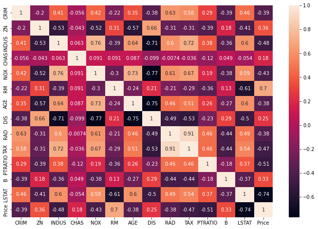

```python
import seaborn as sns
plt.figure(figsize=(12,8))
sns.heatmap(dataset.corr(), annot= True)
plt.show()
```

**Scatter Plot `CRIM` Vs `Price` feature**

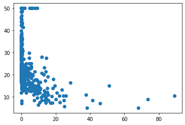

```python
plt.scatter(dataset['CRIM'], dataset['Price'])
plt.show()
```

**Scatter Plot `RM` Vs `Price` feature**

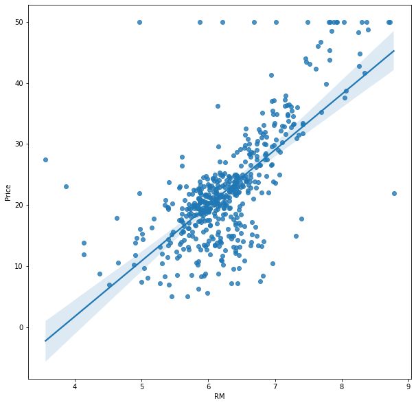

```python
plt.figure(figsize=(10,10))
sns.regplot(x='RM',y='Price',data=dataset)
```

### Conclusion

`RM` and `Price` is positively correlated

The shaded portion near the best fit line means that the best fit line moves in that portion only where the data are more concentrated, the shaded portion is less where the data are less concentrated, the shaded portion is more

**Scatter Plot `LSTAT` Vs `Price` feature**

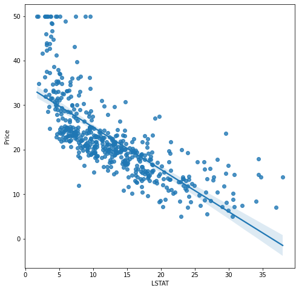

```python
plt.figure(figsize= (8,8))
sns.regplot(x= 'LSTAT',y= 'Price', data= dataset)
plt.show()
```

### Conclusion

`LSTAT` and `Price` feature are negatively correlated

**Scatter Plot `CRIM` Vs `Price` feature**

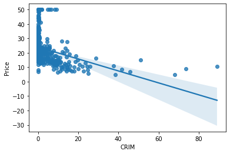

```python
sns.regplot(x= 'CRIM', y= 'Price', data= dataset)
plt.show()
```

### Conclusion

When the `Price` is increaing then `CRIME` is decreasing according to this data.

**Checking the Outliers in the `Price` feature**

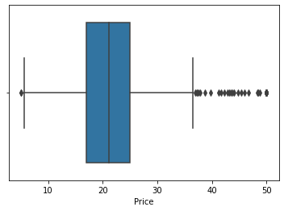

```python
sns.boxplot(dataset['Price'])
plt.show()
```

**Check the Outliers in `CRIM` features**

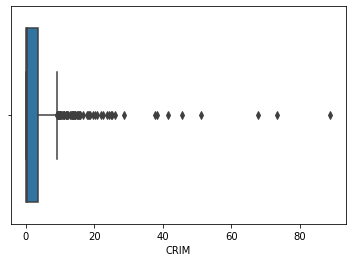

```python
sns.boxplot(dataset['CRIM'])
```

We will not drop the outliers because by doing this there is a chance of lossing important data points and that will effect our prediction

**Creating the Independent and Dependent Features**

```python
x= dataset.iloc[:, :-1]  # Independent Features

y= dataset.iloc[:, -1]   # Dependent Features
```

```python
x.head()
```

|  | CRIM | ZN | INDUS | CHAS | NOX | RM | AGE | DIS | RAD | TAX | PTRATIO | B | LSTAT |
| --- | --- | --- | --- | --- | --- | --- | --- | --- | --- | --- | --- | --- | --- |
| 0 | 0.00632 | 18.0 | 2.31 | 0.0 | 0.538 | 6.575 | 65.2 | 4.0900 | 1.0 | 296.0 | 15.3 | 396.90 | 4.98 |
| 1 | 0.02731 | 0.0 | 7.07 | 0.0 | 0.469 | 6.421 | 78.9 | 4.9671 | 2.0 | 242.0 | 17.8 | 396.90 | 9.14 |
| 2 | 0.02729 | 0.0 | 7.07 | 0.0 | 0.469 | 7.185 | 61.1 | 4.9671 | 2.0 | 242.0 | 17.8 | 392.83 | 4.03 |
| 3 | 0.03237 | 0.0 | 2.18 | 0.0 | 0.458 | 6.998 | 45.8 | 6.0622 | 3.0 | 222.0 | 18.7 | 394.63 | 2.94 |
| 4 | 0.06905 | 0.0 | 2.18 | 0.0 | 0.458 | 7.147 | 54.2 | 6.0622 | 3.0 | 222.0 | 18.7 | 396.90 | 5.33 |

```python
y
```

```
0      24.0
1      21.6
2      34.7
3      33.4
4      36.2
       ...
501    22.4
502    20.6
503    23.9
504    22.0
505    11.9
Name: Price, Length: 506, dtype: float64
```

**Data Splitting**

```python
from sklearn.model_selection import train_test_split

x_train,x_test,y_train,y_test= train_test_split(x, y, test_size= 0.33, random_state= 10)
```

Shape of Independent training dataset

```python
x_train.shape
```

```
(339, 13)
```

Shape of Dependent training Dataset

```python
y_train.shape
```

```
(339,)
```

Shape of Inependent testing Dataset

```python
x_test.shape
```

```
(167, 13)
```

Shape of Dependent testing Dataset

```python
y_test.shape
```

```
(167,)
```

Dependent Training Dataset

```python
y_train
```

```
147    14.6
330    19.8
388    10.2
238    23.7
113    18.7
       ...
320    23.8
15     19.9
484    20.6
125    21.4
265    22.8
Name: Price, Length: 339, dtype: float64
```

Dependent Testing Dataset

```python
y_test
```

```
305    28.4
193    31.1
65     23.5
349    26.6
151    19.6
       ...
442    18.4
451    15.2
188    29.8
76     20.0
314    23.8
Name: Price, Length: 167, dtype: float64
```

**Independent Training Dataset**

```python
x_train
```

|  | CRIM | ZN | INDUS | CHAS | NOX | RM | AGE | DIS | RAD | TAX | PTRATIO | B | LSTAT |
| --- | --- | --- | --- | --- | --- | --- | --- | --- | --- | --- | --- | --- | --- |
| 147 | 2.36862 | 0.0 | 19.58 | 0.0 | 0.871 | 4.926 | 95.7 | 1.4608 | 5.0 | 403.0 | 14.7 | 391.71 | 29.53 |
| 330 | 0.04544 | 0.0 | 3.24 | 0.0 | 0.460 | 6.144 | 32.2 | 5.8736 | 4.0 | 430.0 | 16.9 | 368.57 | 9.09 |
| 388 | 14.33370 | 0.0 | 18.10 | 0.0 | 0.700 | 4.880 | 100.0 | 1.5895 | 24.0 | 666.0 | 20.2 | 372.92 | 30.62 |
| 238 | 0.08244 | 30.0 | 4.93 | 0.0 | 0.428 | 6.481 | 18.5 | 6.1899 | 6.0 | 300.0 | 16.6 | 379.41 | 6.36 |
| 113 | 0.22212 | 0.0 | 10.01 | 0.0 | 0.547 | 6.092 | 95.4 | 2.5480 | 6.0 | 432.0 | 17.8 | 396.90 | 17.09 |
| ... | ... | ... | ... | ... | ... | ... | ... | ... | ... | ... | ... | ... | ... |
| 320 | 0.16760 | 0.0 | 7.38 | 0.0 | 0.493 | 6.426 | 52.3 | 4.5404 | 5.0 | 287.0 | 19.6 | 396.90 | 7.20 |
| 15 | 0.62739 | 0.0 | 8.14 | 0.0 | 0.538 | 5.834 | 56.5 | 4.4986 | 4.0 | 307.0 | 21.0 | 395.62 | 8.47 |
| 484 | 2.37857 | 0.0 | 18.10 | 0.0 | 0.583 | 5.871 | 41.9 | 3.7240 | 24.0 | 666.0 | 20.2 | 370.73 | 13.34 |
| 125 | 0.16902 | 0.0 | 25.65 | 0.0 | 0.581 | 5.986 | 88.4 | 1.9929 | 2.0 | 188.0 | 19.1 | 385.02 | 14.81 |
| 265 | 0.76162 | 20.0 | 3.97 | 0.0 | 0.647 | 5.560 | 62.8 | 1.9865 | 5.0 | 264.0 | 13.0 | 392.40 | 10.45 |

339 rows × 13 columns

**Independent Testing Dataset**

```python
x_test
```

|  | CRIM | ZN | INDUS | CHAS | NOX | RM | AGE | DIS | RAD | TAX | PTRATIO | B | LSTAT |
| --- | --- | --- | --- | --- | --- | --- | --- | --- | --- | --- | --- | --- | --- |
| 305 | 0.05479 | 33.0 | 2.18 | 0.0 | 0.472 | 6.616 | 58.1 | 3.3700 | 7.0 | 222.0 | 18.4 | 393.36 | 8.93 |
| 193 | 0.02187 | 60.0 | 2.93 | 0.0 | 0.401 | 6.800 | 9.9 | 6.2196 | 1.0 | 265.0 | 15.6 | 393.37 | 5.03 |
| 65 | 0.03584 | 80.0 | 3.37 | 0.0 | 0.398 | 6.290 | 17.8 | 6.6115 | 4.0 | 337.0 | 16.1 | 396.90 | 4.67 |
| 349 | 0.02899 | 40.0 | 1.25 | 0.0 | 0.429 | 6.939 | 34.5 | 8.7921 | 1.0 | 335.0 | 19.7 | 389.85 | 5.89 |
| 151 | 1.49632 | 0.0 | 19.58 | 0.0 | 0.871 | 5.404 | 100.0 | 1.5916 | 5.0 | 403.0 | 14.7 | 341.60 | 13.28 |
| ... | ... | ... | ... | ... | ... | ... | ... | ... | ... | ... | ... | ... | ... |
| 442 | 5.66637 | 0.0 | 18.10 | 0.0 | 0.740 | 6.219 | 100.0 | 2.0048 | 24.0 | 666.0 | 20.2 | 395.69 | 16.59 |
| 451 | 5.44114 | 0.0 | 18.10 | 0.0 | 0.713 | 6.655 | 98.2 | 2.3552 | 24.0 | 666.0 | 20.2 | 355.29 | 17.73 |
| 188 | 0.12579 | 45.0 | 3.44 | 0.0 | 0.437 | 6.556 | 29.1 | 4.5667 | 5.0 | 398.0 | 15.2 | 382.84 | 4.56 |
| 76 | 0.10153 | 0.0 | 12.83 | 0.0 | 0.437 | 6.279 | 74.5 | 4.0522 | 5.0 | 398.0 | 18.7 | 373.66 | 11.97 |
| 314 | 0.36920 | 0.0 | 9.90 | 0.0 | 0.544 | 6.567 | 87.3 | 3.6023 | 4.0 | 304.0 | 18.4 | 395.69 | 9.28 |

167 rows × 13 columns

**Standardize the dataset**

```python
from sklearn.preprocessing import StandardScaler
scaler= StandardScaler()  # Initialise
```

```python
scaler
```

```
StandardScaler()
```

**`fit` vs `fit_transform`**

`fit` --- For training data when we do fit it means it is going to calculate mean,S.D. of all the feature separately and `fit_transform` is going to apply the formula $(x-mean)/S.D.$ fit and transform is used for training data and for test data we only do transform

```python
x_train= scaler.fit_transform(x_train)
```

```python
x_test= scaler.transform(x_test) # To avoid datalekage we use transform
```

```python
x_train
```

```
array([[-0.13641471, -0.47928013,  1.16787606, ..., -1.77731527,
         0.39261401,  2.36597873],
       [-0.41777807, -0.47928013, -1.18043314, ..., -0.75987458,
         0.14721899, -0.54115799],
       [ 1.31269177, -0.47928013,  0.95517731, ...,  0.76628645,
         0.19334986,  2.52100705],
       ...,
       [-0.13520965, -0.47928013,  0.95517731, ...,  0.76628645,
         0.17012536,  0.06331026],
       [-0.40281114, -0.47928013,  2.04022838, ...,  0.25756611,
         0.32166792,  0.27238516],
       [-0.33104058,  0.34161649, -1.07552092, ..., -2.56351944,
         0.39993132, -0.34772815]])
```

```python
x_test
```

```
array([[-0.41664568,  0.87519929, -1.33277144, ..., -0.06616502,
         0.41011193, -0.56391444],
       [-0.42063267,  1.98340973, -1.22498491, ..., -1.36108953,
         0.41021798, -1.11860295],
       [-0.41894074,  2.80430634, -1.16175014, ..., -1.12985301,
         0.44765291, -1.16980497],
       ...,
       [-0.40804678,  1.36773726, -1.15169007, ..., -1.54607875,
         0.29854946, -1.18545003],
       [-0.41098494, -0.47928013,  0.19779729, ...,  0.07257689,
         0.20119741, -0.13154186],
       [-0.37856708, -0.47928013, -0.22328875, ..., -0.06616502,
         0.43482111, -0.5141347 ]])
```

## Model Training

```python
from sklearn.linear_model import LinearRegression

from sklearn.model_selection import cross_val_score  ## Cross Validation
```

```python
regression= LinearRegression()
regression
```

```
LinearRegression()
```

```python
regression.fit(x_train, y_train)
```

```
LinearRegression()
```

**Regression Coefficients**

```python
print(regression.coef_)
```

```
[-1.29099218  1.60949999 -0.14031574  0.37201867 -1.76205329  2.22752218
  0.32268871 -3.31184248  2.70288107 -2.09005699 -1.7609799   1.25191514
 -3.83392028]
```

```python
print(regression.intercept_)
```

```
22.077286135693246
```

```python
mse= cross_val_score(regression,x_train,y_train,scoring='neg_mean_squared_error',cv=10)
mse
```

```
array([-31.92442096, -16.22454874, -13.4224175 , -22.08071899,
       -22.50456479, -22.25101523, -17.0099947 , -17.398274  ,
       -20.41812039, -43.67702014])
```

```python
np.mean(mse)
```

```
-22.691109542718042
```

**prediction for test data**

```python
reg_pred= regression.predict(x_test)
reg_pred
```

```
array([31.43849583, 31.98794389, 30.99895559, 22.31396689, 18.89492791,
       16.21371128, 35.9881236 , 14.81264582, 25.04500847, 37.12806894,
       21.49110158, 30.88757187, 28.05752881, 34.05600093, 33.75791114,
       40.63880011, 24.24023412, 23.41351375, 25.54158122, 21.34135664,
       32.71699711, 17.88341061, 25.49549436, 25.01006418, 32.54102925,
       20.48979076, 19.48816948, 16.92733183, 38.38530857,  0.36265208,
       32.42715816, 32.15306983, 26.10323665, 23.79611814, 20.67497128,
       19.69393973,  3.50784614, 35.26259797, 27.04725425, 27.66164435,
       34.35132103, 29.83057837, 18.40939436, 31.56953795, 17.91877807,
       28.50042742, 19.49382421, 21.69553078, 38.0954563 , 16.44490081,
       24.58507284, 19.67889486, 24.53954813, 34.30610423, 26.74699088,
       34.87803562, 21.06219662, 19.87980936, 18.68725139, 24.71786624,
       19.96344041, 23.56002479, 39.57630226, 42.81994338, 30.37060855,
       17.03737245, 23.83719412,  3.2425022 , 31.5046382 , 28.63779884,
       18.49288659, 27.14115768, 19.67125483, 25.34222917, 25.05430467,
       10.29463949, 38.96369453,  8.26774249, 18.52214761, 30.34082002,
       22.87681099, 20.96680268, 20.04604103, 28.73415756, 30.81726786,
       28.23002473, 26.28588806, 31.59181918, 22.13093608, -6.48201197,
       21.53000756, 19.90826887, 24.96686716, 23.44746617, 19.28521216,
       18.75729874, 27.40013804, 22.17867402, 26.82972   , 23.39779064,
       23.9260607 , 19.16632572, 21.09732823, 11.01452286, 13.7692535 ,
       20.74596484, 23.54892211, 14.04445469, 28.88171403, 15.77611741,
       15.25195598, 22.429474  , 26.60737213, 28.88742175, 24.29797261,
       18.26839956, 16.26943281, 17.40100292, 15.53131616, 21.27868825,
       33.78464602, 30.00899396, 21.16115702, 13.95560661, 16.18475215,
       29.30998858, 13.1866784 , 22.08393725, 24.34499386, 31.86829501,
       33.45923602,  5.90671516, 35.20153265, 24.17614831, 17.54200544,
       24.25032915, 28.44671354, 34.50123773,  6.33164665,  1.93565618,
       28.40727267, 12.56461105, 18.31045646, 19.71015745,  5.50105857,
       14.51366874, 37.193992  , 25.81821367, 23.31632083, 26.43254504,
       11.38255141, 20.46224115, 35.27645709, 20.57841598, 11.48799917,
       16.23913171, 24.56511742, 10.53131603, 15.07115005, 25.98488217,
       11.2136222 , 11.695686  , 19.40437966, 19.58768384, 32.43800883,
       22.66170871, 25.68576052])
```

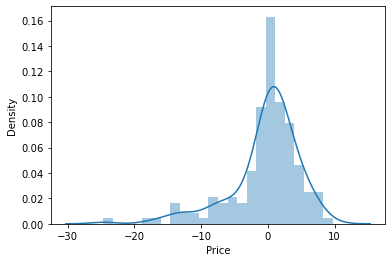

```python
import seaborn as sns
sns.distplot(reg_pred-y_test)
plt.show()
```

### Assumptions of Linear Regression

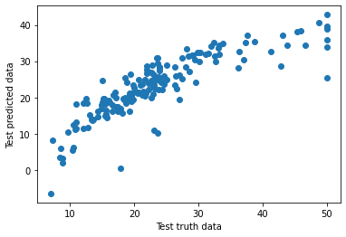

```python
plt.scatter(y_test,reg_pred)
plt.xlabel("Test truth data")
plt.ylabel('Test predicted data')
plt.show()
```

#### Conclusion

Our prediction is good enough

**Residuals**

```python
residual= y_test-reg_pred
residual
```

```
305   -3.038496
193   -0.887944
65    -7.498956
349    4.286033
151    0.705072
         ...
442   -1.004380
451   -4.387684
188   -2.638009
76    -2.661709
314   -1.885761
Name: Price, Length: 167, dtype: float64
```

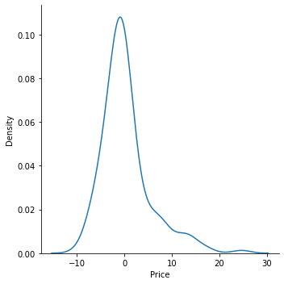

```python
sns.displot(residual, kind= 'kde')
plt.show()
```

### Conclusion

The graph of residuals is normally distributed but with some outliers in right side.

**Scatter Plot between `Prediction` and `Residuals`**

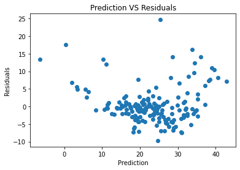

```python
plt.scatter(reg_pred, residual)
plt.xlabel("Prediction")
plt.ylabel("Residuals")
plt.title("Prediction VS Residuals")
plt.show()
```

### Performance Metrics

```python
from sklearn.metrics import mean_squared_error
from sklearn.metrics import mean_absolute_error

print("Mean Square Error :", mean_squared_error(y_test, reg_pred))

print("Root Mean Square Error :", np.sqrt(mean_squared_error(y_test, reg_pred)))

print("Mean Absolute Error :", mean_absolute_error(y_test, reg_pred))
```

```
Mean Square Error : 27.100991709962475
Root Mean Square Error : 5.205861284164463
Mean Absolute Error : 3.520658529879791
```

### R square ($R^2$)

```python
from sklearn.metrics import r2_score

score= r2_score(y_test,reg_pred)
score
```

```
0.7165219393967556
```

### Adjusted R square ($R^2_{adj.}$)

```python
1-(1-score)*(len(y_test)-1)/(len(y_test)-x_test.shape[1]-1)
```

```
0.6924355682343883
```

### Performing Linear Regression Using **statsmodels** library

```python
import statsmodels.formula.api as smf
```

```python
lm= smf.ols(formula= "Price~ CRIM+ ZN+ INDUS+ CHAS+ NOX+ RM+ AGE+ DIS+ RAD+ TAX+ B+ LSTAT", data= dataset).fit()
lm.summary()
```

OLS Regression Results

| Dep. Variable: | Price | R-squared: | 0.713 |
| --- | --- | --- | --- |
| Model: | OLS | Adj. R-squared: | 0.706 |
| Method: | Least Squares | F-statistic: | 101.9 |
| Date: | Mon, 17 Oct 2022 | Prob (F-statistic): | 4.56e-125 |
| Time: | 10:32:45 | Log-Likelihood: | -1524.7 |
| No. Observations: | 506 | AIC: | 3075. |
| Df Residuals: | 493 | BIC: | 3130. |
| Df Model: | 12 |  |  |
| Covariance Type: | nonrobust |  |  |

|  | coef | std err | t | P>\|t\| | [0.025 | 0.975] |
| --- | --- | --- | --- | --- | --- | --- |
| Intercept | 14.1689 | 4.294 | 3.300 | 0.001 | 5.732 | 22.605 |
| CRIM | -0.1030 | 0.035 | -2.981 | 0.003 | -0.171 | -0.035 |
| ZN | 0.0775 | 0.014 | 5.652 | 0.000 | 0.051 | 0.104 |
| INDUS | -0.0376 | 0.064 | -0.587 | 0.558 | -0.164 | 0.088 |
| CHAS | 3.2744 | 0.902 | 3.630 | 0.000 | 1.502 | 5.047 |
| NOX | -8.5977 | 3.792 | -2.267 | 0.024 | -16.048 | -1.148 |
| RM | 4.2952 | 0.434 | 9.901 | 0.000 | 3.443 | 5.148 |
| AGE | -0.0068 | 0.014 | -0.493 | 0.622 | -0.034 | 0.020 |
| DIS | -1.6115 | 0.209 | -7.718 | 0.000 | -2.022 | -1.201 |
| RAD | 0.2148 | 0.069 | 3.135 | 0.002 | 0.080 | 0.349 |
| TAX | -0.0144 | 0.004 | -3.653 | 0.000 | -0.022 | -0.007 |
| B | 0.0087 | 0.003 | 3.067 | 0.002 | 0.003 | 0.014 |
| LSTAT | -0.5415 | 0.053 | -10.166 | 0.000 | -0.646 | -0.437 |

| Omnibus: | 161.318 | Durbin-Watson: | 0.983 |
| --- | --- | --- | --- |
| Prob(Omnibus): | 0.000 | Jarque-Bera (JB): | 622.859 |
| Skew: | 1.411 | Prob(JB): | 5.59e-136 |
| Kurtosis: | 7.645 | Cond. No. | 1.24e+04 |

Notes:  
[1] Standard Errors assume that the covariance matrix of the errors is correctly specified.  
[2] The condition number is large, 1.24e+04. This might indicate that there are  
strong multicollinearity or other numerical problems.

# Ridge Regression Algorithm

```python
from sklearn.linear_model import Ridge
from sklearn.model_selection import GridSearchCV
```

```python
ridge_regressor= Ridge()
ridge_regressor
```

```
Ridge()
```

```python
parameters= {'alpha':[1,2,5,10,20,30,40,50,60,70,80,90]}

ridgecv= GridSearchCV(ridge_regressor, parameters, scoring= 'neg_mean_squared_error', cv= 5)
ridgecv.fit(x_train, y_train)
```

```
GridSearchCV(cv=5, estimator=Ridge(),
             param_grid={'alpha': [1, 2, 5, 10, 20, 30, 40, 50, 60, 70, 80,
                                   90]},
             scoring='neg_mean_squared_error')
```

**Best Parameters**

```python
ridgecv.best_params_
```

```
{'alpha': 5}
```

**Best Mean Scored Error**

```python
ridgecv.best_score_
```

```
-23.04953195588414
```

```python
ridge_pred= ridgecv.predict(x_test)
ridge_pred
```

```
array([30.94893945, 31.95230552, 30.83799576, 22.92515291, 19.06064421,
       16.23530635, 35.88249364, 14.95641351, 24.87647045, 36.93516109,
       21.49803619, 30.77541167, 27.74128325, 33.71782021, 33.61550173,
       40.5256606 , 24.39052554, 23.08079973, 25.4775641 , 21.72623058,
       32.56414106, 17.89589523, 25.5072399 , 25.04583898, 32.731564  ,
       20.48310157, 19.62667757, 16.99278046, 38.2589971 ,  0.26121174,
       32.49320583, 31.92195512, 26.2493227 , 23.88495547, 20.53407925,
       19.79600079,  3.77053503, 34.85557017, 26.91615746, 27.5962946 ,
       34.29501115, 29.56336019, 18.35920959, 31.48627405, 17.96762164,
       28.54935954, 19.5050633 , 21.50771653, 37.82319439, 16.59555187,
       24.48011234, 19.59543258, 24.32161035, 34.41441111, 26.73254221,
       34.68317698, 21.15136538, 19.89830841, 18.5570366 , 24.69580624,
       20.12960233, 23.65864042, 39.69027457, 42.68897335, 30.2869122 ,
       17.19710701, 23.87053511,  3.20992972, 31.14003141, 29.15428589,
       18.51355744, 27.1744544 , 19.56074649, 25.09162549, 25.14546943,
       10.44155549, 38.84182583,  8.28302111, 18.47185675, 30.54746519,
       22.92967539, 21.50795126, 20.24959299, 28.59358122, 30.79081449,
       28.19678651, 26.2771689 , 31.70452645, 22.26688629, -6.18391389,
       21.67857974, 19.86773005, 24.96351394, 23.56914874, 19.17798765,
       18.98255788, 27.30404466, 22.24680048, 26.6058877 , 23.42554266,
       23.94278732, 19.25384855, 21.11732574, 10.54093294, 13.94150299,
       20.92317871, 23.30715277, 14.69404542, 28.79394261, 16.14908085,
       15.30776747, 22.2656828 , 26.71520051, 28.83700364, 24.12327293,
       18.25040509, 16.26546233, 17.62208197, 15.78209511, 21.10655989,
       33.49710904, 30.27899909, 21.20645117, 14.37007552, 16.3423865 ,
       29.10094835, 13.19620855, 22.02910262, 24.36128776, 31.91169644,
       32.93066796,  6.1545445 , 34.94863773, 24.5505649 , 17.60402831,
       24.34183878, 28.33322387, 34.3799502 ,  6.30807967,  2.41010632,
       28.37596329, 12.68812025, 18.35915069, 19.92920495,  5.57912262,
       14.13497165, 36.99038186, 26.00842107, 23.23797065, 26.26166989,
       11.55346778, 20.59291017, 35.33746588, 20.73807859, 11.35990806,
       16.80598192, 24.58823052, 10.44647644, 15.38002796, 26.08498801,
       11.29562452, 11.73306729, 19.35937246, 19.60813781, 32.37536376,
       22.69502669, 25.67237795])
```

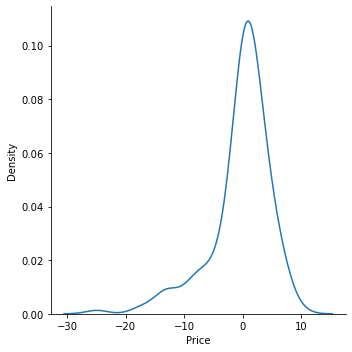

```python
import seaborn as sns
sns.displot(ridge_pred-y_test, kind= 'kde')
plt.show()
```

#### Assumptions of linear Regression

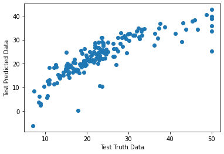

```python
plt.scatter(y_test, ridge_pred)
plt.xlabel("Test Truth Data")
plt.ylabel('Test Predicted Data')
plt.show()
```

**Residuals**

```python
residual= y_test-ridge_pred
residual
```

```
305   -2.548939
193   -0.852306
65    -7.337996
349    3.674847
151    0.539356
         ...
442   -0.959372
451   -4.408138
188   -2.575364
76    -2.695027
314   -1.872378
Name: Price, Length: 167, dtype: float64
```

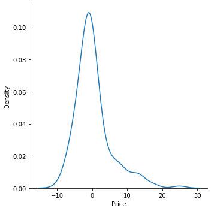

```python
sns.displot(residual, kind= 'kde')
plt.show()
```

**Scatter Plot with `Residuals` and `Prediction`**

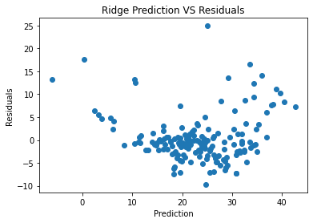

```python
plt.scatter(ridge_pred, residual)
plt.xlabel("Prediction")
plt.ylabel("Residuals")
plt.title("Ridge Prediction VS Residuals")
plt.show()
```

### Performance Metrics

```python
from sklearn.metrics import mean_squared_error
from sklearn.metrics import mean_absolute_error

print("Mean Square Error :", mean_squared_error(y_test, ridge_pred))

print("Root Mean Square Error :", np.sqrt(mean_squared_error(y_test, ridge_pred)))

print("Mean Absolur Error :", mean_absolute_error(y_test, ridge_pred))
```

```
Mean Square Error : 27.017970344577275
Root Mean Square Error : 5.197881332290809
Mean Absolur Error : 3.5019597897900288
```

#### R-square $(R^2)$

```python
from sklearn.metrics import r2_score

ridge_score= r2_score(y_test, ridge_pred)
ridge_score
```

```
0.7173903480476235
```

#### Adjusted R square $(R^2_{adj.})$

```python
1-(1-ridge_score)*(len(y_test)-1)/(len(y_test)-x_test.shape[1]-1)
```

```
0.6933777632412124
```

# Lasso Regression

```python
from sklearn.linear_model import Lasso
```

```python
lasso= Lasso()
lasso
```

```
Lasso()
```

```python
parameters= {'alpha':[1,2,5,10,20,30,40,50,60,70,80,90]}

lassocv= GridSearchCV(lasso, parameters, scoring= 'neg_mean_squared_error', cv= 5)
lassocv.fit(x_train, y_train)
```

```
GridSearchCV(cv=5, estimator=Lasso(),
             param_grid={'alpha': [1, 2, 5, 10, 20, 30, 40, 50, 60, 70, 80,
                                   90]},
             scoring='neg_mean_squared_error')
```

```python
# print(lassocv.best_params_)
lassocv.best_score_
```

```
-28.53070382049192
```

```python
lasso_pred= lassocv.predict(x_test)
lasso_pred
```

```
array([25.64194382, 29.81425297, 27.94324255, 27.55256464, 20.99640298,
       18.74520609, 34.28217994, 15.93009427, 20.70883387, 34.07542731,
       19.90502439, 26.60490365, 24.07990755, 29.92866139, 29.22037693,
       36.40160499, 26.2514407 , 19.88117334, 23.967085  , 22.50869347,
       30.87428332, 18.78300957, 23.92041383, 25.68996484, 32.43275786,
       21.59346217, 20.77097939, 19.17145706, 34.09829244,  2.83421427,
       30.5699873 , 29.29565261, 26.85558827, 25.25346658, 19.26477827,
       19.73302762,  7.84289608, 29.77239449, 25.40207471, 25.60513357,
       32.3846261 , 26.89227407, 18.03007537, 29.36340326, 18.91119501,
       27.26813644, 20.46203931, 21.03622196, 34.39115891, 18.05973586,
       23.67935365, 18.6389767 , 22.52686697, 32.78082702, 26.03741902,
       30.39354515, 20.51475327, 20.94796259, 17.76992156, 24.71515119,
       21.39562999, 22.87363803, 36.66878913, 37.88636344, 28.19838095,
       17.67593653, 24.95639783,  5.16197744, 27.44103022, 33.73592095,
       19.49826488, 28.55803328, 19.79798303, 21.76346312, 24.39060267,
       10.72390653, 35.69760879,  8.87515321, 19.7342389 , 30.44923304,
       23.5731452 , 25.969039  , 21.53759864, 26.56759106, 29.08985079,
       27.11618087, 27.52241607, 31.13762774, 25.19009251,  1.294237  ,
       24.63082225, 20.35958514, 25.20780706, 25.3136586 , 19.78586427,
       20.81458041, 26.18578331, 20.65389528, 23.63766687, 22.07598695,
       24.48709112, 20.92346851, 21.99207783, 11.28215423, 15.85225507,
       22.37860011, 20.11691913, 17.8652717 , 27.92655648, 20.66334411,
       16.27505897, 21.25931319, 25.72062784, 25.92038934, 22.43890052,
       18.21105925, 13.73609426, 19.70671479, 19.16823222, 20.81634433,
       28.98351303, 31.19474714, 20.47647933, 14.48614909, 18.32476473,
       25.90552665, 15.20476004, 22.61771889, 24.11123534, 30.06699424,
       27.18076864, 10.97444888, 29.31613765, 29.11544566, 18.4851049 ,
       25.5516343 , 26.58527747, 29.79753531,  7.90378337, 13.9914479 ,
       27.53958439, 15.07581206, 19.1010104 , 20.2136539 ,  9.56591918,
       12.35215313, 32.65105454, 27.04505972, 22.60389757, 23.38431025,
       18.14439345, 21.46916879, 33.35149732, 21.68370567, 11.686795  ,
       22.46129098, 24.462044  , 10.63445232, 17.62333713, 25.46239518,
       13.61074004, 15.25814185, 19.3752538 , 20.11939071, 29.36108994,
       22.66082095, 25.30493792])
```

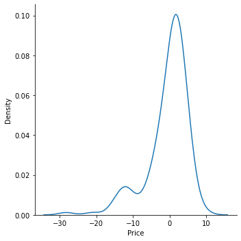

```python
import seaborn as sns
sns.displot(lasso_pred-y_test, kind= 'kde')
plt.show()
```